# Rendu intermédiaire_Projet MLB _ M2_MODE

P. Cuchot, P. Fournier, M. Faucher

14/11/2020

# Introduction

Pour ce projet, nous avons choisi de suivre la même démarche que Tarek Hattab , en changeant toutefois le sujet d’étude. Nous étudierons ici la distribution de *Gadus morhua*. Les données de présences et de pseudo-absences sont obtenues en réalisant la première partie du script suivant : https://github.com/TarekHattab/SDM. Après avoir réalisé des modèles de prédiction de présence selon trois méthodes différentes, nous allons utiliser le modèle le plus efficace pour réaliser une prédiction de distribution de la population dans un scénario de réchauffement du milieu de vie dû au changement climatique.

### Chargement des données

```r
data <- read.csv("https://raw.githubusercontent.com/martin-faucher/projet-MODE-MLB/main/data_OCC.csv")
data <- as.data.frame(data) # transformation en data.frame
names(data)[1] <- "type" # changement du nom de la premiere colonne
```

### Chargement des packages

```r
library(mgcv)
library(randomForest)
```

### Exploration des données

```r
table(data$type)
```

```
##
##    0    1
## 1000  739
```

Les données utilisées ici comportent 1000 données de pseudo-absences et 739 données de présence.

On affiche la répartition des données de températures et de salinité en fonction de la présence ou non de Gadus morhua.

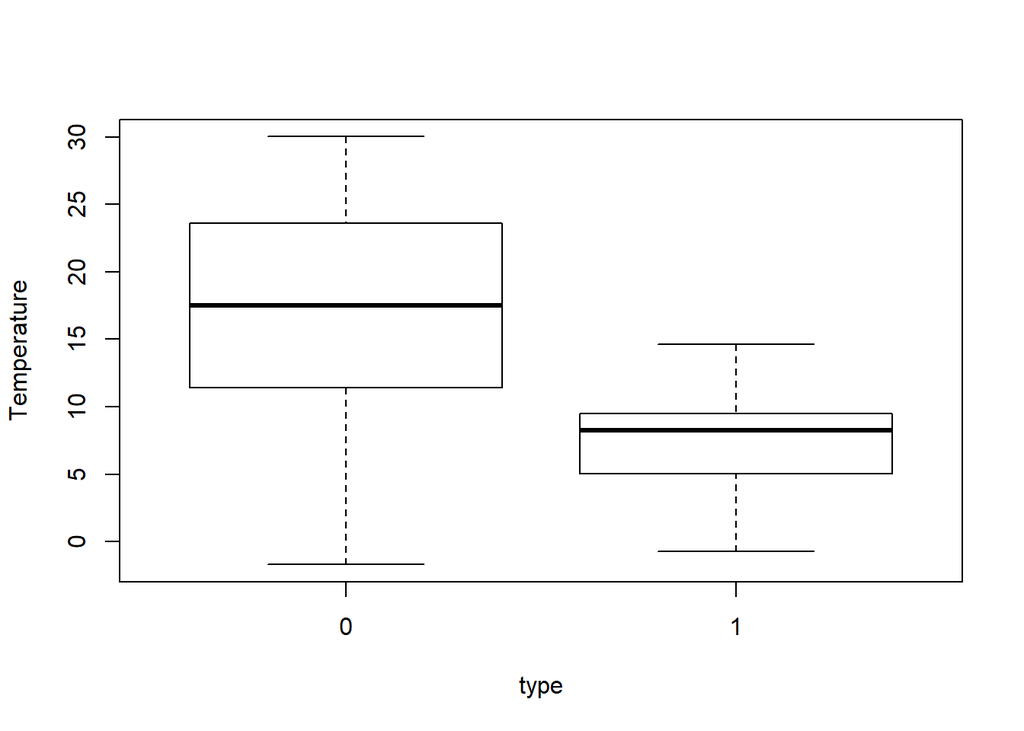

```r
boxplot(Temperature~type, data=data)
```

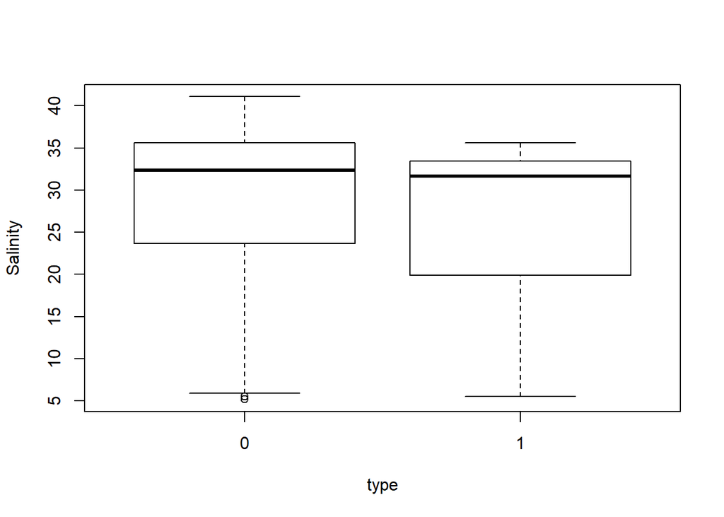

```r
boxplot(Salinity~type, data=data)
```

### Séparation des données

Ici, on crée une fonction qui aura pour but de séparer le jeu de données en deux. La première partie servira pour construire les modèles, la seconde pour les valider.

```r
train_test_split <- function (X, test_size=0.25){
  # On separe le jeu de données selon la présence ou la pseudo-absence
  # Pour pouvoir conserver les mêmes proportions dans les jeux de données
  # d'entraînement
  data_1 <- X[X$type==1,]
  data_0 <- X[X$type==0,]

  #On tire des individus au hasard dans les deux jeux de données
  samp_1_train <- sample(1:nrow(data_1), round(test_size*nrow(data_1)))
  samp_0_train <- sample(1:nrow(data_0), round(test_size*nrow(data_0)))

  #On rassemble les données de présence et de pseudo-absence
  data_train <- rbind(data_1[-samp_1_train,], data_0[-samp_0_train,])
  data_test <- rbind(data_1[samp_1_train,], data_0[samp_0_train,])

  # data_list rassemble les deux jeux de données dans une liste
  data_list <- list(data_train, data_test)
  names(data_list) <- c("train","test")

  return(data_list)
}
```

On applique la fonction sur notre jeu de données.

```r
data_split <- train_test_split(data)
```

## Modélisation

On décide de modéliser la présence de poisson à l’aide de trois méthodes : * Modèle linaire généralisé (GLM) * Modèle additif généralisé (GAM) * Random Forest (RF)

### Modèle linéaire généralisé

```r
B = 10 # B = nombre de fois qu'on réalise une cross-validation
moy_succ <-  c()

for (b in 1:B){
  X <- train_test_split(data)
  train = X$train
  test = X$test

  mod_glm <- glm(type~Temperature+Salinity,
             family="binomial", data=train)

  y_pred = predict(mod_glm,test, type = "response")
  test <- cbind(test,y_pred)
  pres_test <- which(test[,1] == 1)
  moy_succ <- c(moy_succ,mean(test[pres_test,4]))
}

print(mean(moy_succ))
```

```
## [1] 0.5770293
```

```r
summary(mod_glm)
```

```
##
## Call:
## glm(formula = type ~ Temperature + Salinity, family = "binomial",
##     data = train)
##
## Deviance Residuals:
##     Min       1Q   Median       3Q      Max
## -2.1217  -0.7767  -0.3504   1.0698   1.4601
##
## Coefficients:
##              Estimate Std. Error z value Pr(>|z|)
## (Intercept)  0.900861   0.182306   4.941 7.75e-07 ***
## Temperature -0.172135   0.010633 -16.189  < 2e-16 ***
## Salinity     0.027374   0.006778   4.039 5.37e-05 ***
## ---
## Signif. codes:  0 '***' 0.001 '**' 0.01 '*' 0.05 '.' 0.1 ' ' 1
##
## (Dispersion parameter for binomial family taken to be 1)
##
##     Null deviance: 1778.2  on 1303  degrees of freedom
## Residual deviance: 1378.1  on 1301  degrees of freedom
## AIC: 1384.1
##
## Number of Fisher Scoring iterations: 4
```

On évalue maintenant le modèle avec les données de test.

```r
y_train <-  predict(mod_glm, type="response")
data_split$train$proba <- y_train

y_test <-  predict(mod_glm, data_split$test, type = "response")
data_split$test$proba <- y_test

m <- mean(data_split$test[data_split$test$type==1,]$proba)
```

Ici, on peut voir que la probabilité moyenne pour une données d’occurence d’être considérée comme telle par le modèle est de 0.5812391.

### GAM

```r
B = 10 # B = nombre de fois qu'on réalise une cross-validation
moy_succ <-  c()

for (b in 1:B){
  X <- train_test_split(data)
  train = X$train
  test = X$test

  mod_GAM <- gam(type ~ Salinity + Temperature,
                 family = binomial("logit"), data = train, method = "REML")

  y_pred = predict(mod_GAM,test, type = "response")
  test <- cbind(test,y_pred)
  pres_test <- which(test[,1] == 1)
  moy_succ <- c(moy_succ,mean(test[pres_test,4]))
}
```

Ici, on peut voir que la probabilité moyenne pour une données d’occurence d’être considérée comme telle par le modèle est de 0.5831963.

### Random forest

```r
mse_rf = NULL ; B = 10 # nombre de fois qu'on réalise une cross-validation

moy_succ_rf <-  c()

for (b in 1:B){
  X <- train_test_split(data)
  train = X$train
  test = X$test

  RF = randomForest(type~.,data=train,mtry=20,control=rpart.control(maxdepth=5, minsplit=15), do.trace = F)
  # maxdepth = prof. max. de chq. arbre
  # minsplit = n. min. d'obs. dans noeud avant qu'une séparation soit possible
  y_pred = predict(RF,test, type = "response")
  test <- cbind(test,y_pred)
  pres_test <- which(test[,1] == 1)
  moy_succ_rf <- c(moy_succ_rf,mean(test[pres_test,4]))
}
m_rf <- mean(moy_succ_rf)
```

Ici, on peut voir que la probabilité moyenne pour une données d’occurence d’être considérée comme telle par le modèle est de 0.9609941.

La méthode Random Forest semble la plus efficace pour prédire la présence de Gadus morhua. Il nous reste à utiliser le modèle sur des données de salinité et de température simulées pour 2030 et 2050 afin d’estimer l’aire de distribution de la morue Gadus morhua dans 10 et 30 ans.